# HW1

Alper Yılmaz,Yagız Arslan

11 05 2020

Q1 A

In this part we are asked to establish a fraction plot consists of 1 to 10 dimensional 1000 sample data, and their eculedian distances to all data.

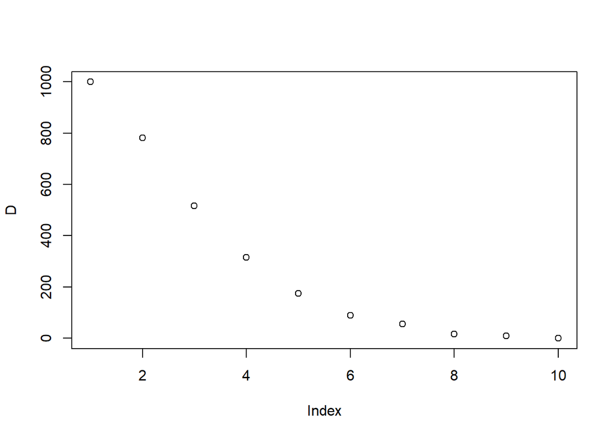

```r
#dimension_1
nof_samples=1000
data_points1=runif(nof_samples,-1,1)
data_points1=matrix(data_points1,ncol=1)
euclidean_distance1=sqrt((data_points1[ ,1]-0)^2)
x1=euclidean_distance1<1
r1=sum(x1)

#dimension_2
nof_samples=1000
data_points2=runif(nof_samples*2,-1,1)
data_points2=matrix(data_points2,ncol=2)
euclidean_distance2=sqrt((data_points2[ ,1]-0)^2 + (data_points2[ ,2]-0)^2)
x2=euclidean_distance2<1
r2=sum(x2)

#dimension_3
nof_samples=1000
data_points3=runif(nof_samples*3,-1,1)
data_points3=matrix(data_points3,ncol=3)
euclidean_distance3=sqrt((data_points3[ ,1]-0)^2 + (data_points3[ ,2]-0)^2 + (data_points3[,3]-0)^2)
x3=euclidean_distance3<1
r3=sum(x3)

#dimension_4
nof_samples=1000
data_points4=runif(nof_samples*4,-1,1)
data_points4=matrix(data_points4,ncol=4)
euclidean_distance4=sqrt((data_points4[ ,1]-0)^2 + (data_points4[ ,2]-0)^2 + (data_points4[,3]-0)^2 + (data_points4[,4]-0)^2)
x4=euclidean_distance4<1
r4=sum(x4)

#dimension_5
nof_samples=1000
data_points5=runif(nof_samples*5,-1,1)
data_points5=matrix(data_points5,ncol=5)
euclidean_distance5=sqrt((data_points5[ ,1]-0)^2 + (data_points5[ ,2]-0)^2 + (data_points5[,3]-0)^2 + (data_points5[,4]-0)^2 + (data_points5[,5]-0)^2)
x5=euclidean_distance5<1
r5=sum(x5)

#dimension_6
nof_samples=1000
data_points6=runif(nof_samples*6,-1,1)
data_points6=matrix(data_points6,ncol=6)
euclidean_distance6=sqrt((data_points6[ ,1]-0)^2 + (data_points6[ ,2]-0)^2 + (data_points6[,3]-0)^2 +
                           (data_points6[,4]-0)^2 + (data_points6[,5]-0)^2 + (data_points6[,6]-0)^2)
x6=euclidean_distance6<1
r6=sum(x6)

#dimension_7
nof_samples=1000
data_points7=runif(nof_samples*7,-1,1)
data_points7=matrix(data_points7,ncol=7)
euclidean_distance7=sqrt((data_points7[ ,1]-0)^2 + (data_points7[ ,2]-0)^2 + (data_points7[,3]-0)^2 +
                           (data_points7[,4]-0)^2 + (data_points7[,5]-0)^2 + (data_points7[,6]-0)^2 +
                           (data_points7[,6]-0)^2)
x7=euclidean_distance7<1
r7=sum(x7)

#dimension_8
nof_samples=1000
data_points8=runif(nof_samples*8,-1,1)
data_points8=matrix(data_points8,ncol=8)
euclidean_distance8=sqrt((data_points8[ ,1]-0)^2 + (data_points8[ ,2]-0)^2 + (data_points8[,3]-0)^2 +
                           (data_points8[,4]-0)^2 + (data_points8[,5]-0)^2 + (data_points8[,6]-0)^2 +
                           (data_points8[,7]-0)^2 + (data_points8[,8]-0)^2)
x8=euclidean_distance8<1
r8=sum(x8)

#dimension_9
nof_samples=1000
data_points9=runif(nof_samples*9,-1,1)
data_points9=matrix(data_points9,ncol=9)
euclidean_distance9=sqrt((data_points9[ ,1]-0)^2 + (data_points9[ ,2]-0)^2 + (data_points9[,3]-0)^2 +
                           (data_points9[,4]-0)^2 + (data_points9[,5]-0)^2 + (data_points9[,6]-0)^2 +
                           (data_points9[,7]-0)^2 + (data_points9[,8]-0)^2 + (data_points9[,9]-0)^2)
x9=euclidean_distance9<1
r9=sum(x9)

#dimension_10
nof_samples=1000
data_points10=runif(nof_samples*10,-1,1)
data_points10=matrix(data_points10,ncol=10)
euclidean_distance10=sqrt((data_points10[ ,1]-0)^2 + (data_points10[ ,2]-0)^2 + (data_points10[,3]-0)^2 +
                            (data_points10[,4]-0)^2 + (data_points10[,5]-0)^2 + (data_points10[,6]-0)^2 +
                            (data_points10[,7]-0)^2 + (data_points10[,8]-0)^2 + (data_points10[,9]-0)^2 +
                            (data_points10[,10]-0)^2)
x10=euclidean_distance10<1
r10=sum(x10)


D=c(r1,r2,r3,r4,r5,r6,r7,r8,r9,r10)
plot(D)
```

As a result we obtained the higher gets the dimension the lower gets the fraction, meaning that as the higher we go in dimension the curse of dimensionalty welcomes us as the fraction of hypershere to hypercube gets down to lower numbers. This is because as the dimensions increase the distance between the points in n dimensional space get further from each other with a higher probability.

Q1 B

In this part we did the same procedure as the pi estimation in the class and the dimensional fraction as in the first part. We did for 2d and 3d. The corresonding pi estimation and fraciton in the scattered plot

```r
#2D
nof_samples=1000
data_points=runif(nof_samples*2,-1,1)
data_points=matrix(data_points,ncol=2)
plot(data_points)
euclidean_distance=sqrt((data_points[ ,1]-0)^2 + (data_points[ ,2]-0)^2)
is_in_circle=euclidean_distance<=1
nof_sphere=sum(is_in_circle)
estimated_pi=(nof_sphere/nof_samples)*6
print(estimated_pi)
```

```
## [1] 4.824
```

```r
print(pi)
```

```
## [1] 3.141593
```

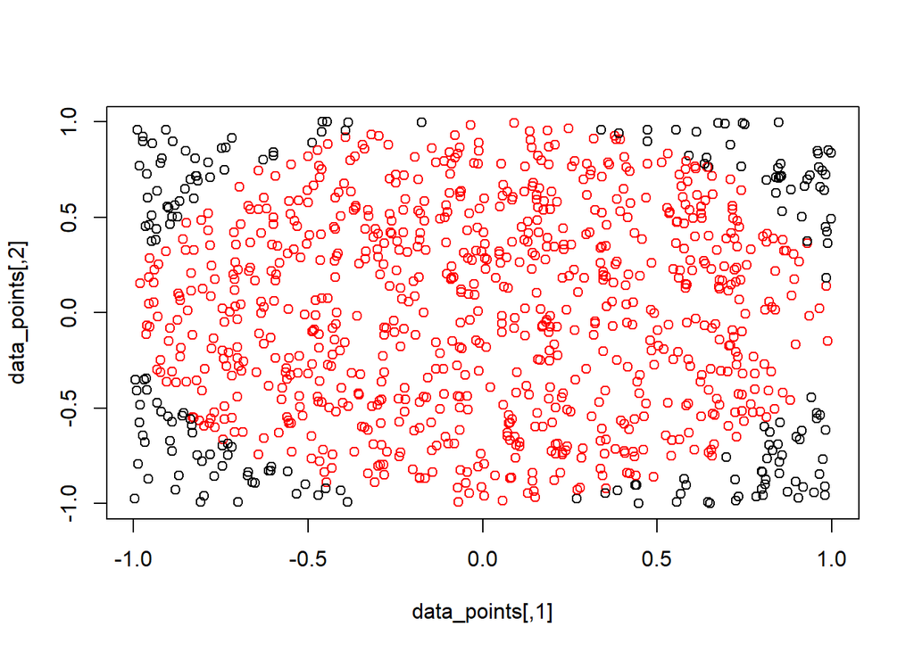

```r
points(data_points,col=as.numeric(is_in_circle)+1)
```

```r
#3D
library(scatterplot3d)
nof_samples=1000
data_points=runif(nof_samples*3,-1,1)
data_points=matrix(data_points,ncol=3)
euclidean_distance=sqrt((data_points[ ,1]-0)^2 + (data_points[ ,2]-0)^2+(data_points[ ,3]-0)^2)
is_in_1=euclidean_distance<=1
sphere=sum(is_in_1)
estimated_pi=sphere/nof_samples*6
print(estimated_pi)
```

```
## [1] 3.078
```

```r
print(pi)
```

```
## [1] 3.141593
```

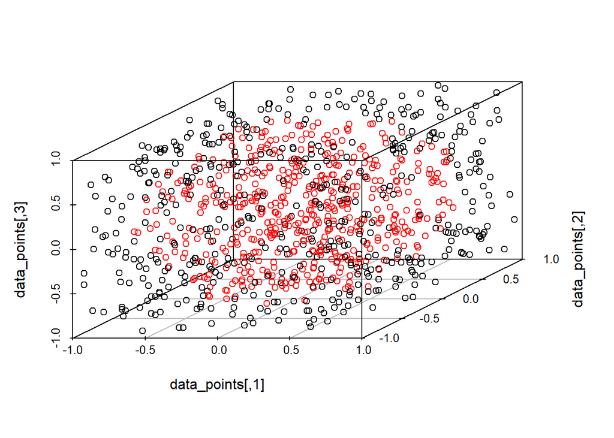

```r
scatterplot3d(data_points,color=as.numeric(is_in_1)+1)
```

For each dimension is uniformly randomly distributed between -1 and +1 we used Rnorm function for the 100 sample with runif function for the first 1000 examples.

Q1 C

```r
#dimension 1
require(proxy)
a=matrix(runif(1000),ncol=1)
b=matrix(rnorm(100),ncol=1)
dist_mat=proxy::dist(a,b)
min1_1=min(dist_mat[,1])
min1_1
```

```
## [1] 0.4779851
```

```r
average1=as.matrix(ave(c(min1_1)))
x1_1=average1[1,]
x1_1
```

```
## [1] 0.4779851
```

```r
#dimension 2
a2=matrix(runif(2000),ncol=2)
b2=matrix(rnorm(200),ncol=2)
dist_mat2=proxy::dist(a2,b2)
min2_1=min(dist_mat2[,1])
min2_1
```

```
## [1] 0.961763
```

```r
min2_2=min(dist_mat2[,2])
min2_2
```

```
## [1] 0.06488699
```

```r
x2=c(min2_1,min2_2)
average2=ave(x2)
average2=as.matrix(average2)
x2_1=average2[1,]
x2_1
```

```
## [1] 0.513325
```

```r
#dimension 3
a3=matrix(runif(3000),ncol=3)
b3=matrix(rnorm(300),ncol=3)
dist_mat3=proxy::dist(a3,b3)
min3_1=min(dist_mat3[,1])
min3_1
```

```
## [1] 0.5830581
```

```r
min3_2=min(dist_mat3[,2])
min3_2
```

```
## [1] 3.113188
```

```r
min3_3=min(dist_mat3[,3])
min3_3
```

```
## [1] 0.5504301
```

```r
x3=c(min3_1,min3_2,min3_3)
average3=ave(x3)
average3=as.matrix(average3)
x3_1=average3[1,]
x3_1
```

```
## [1] 1.415559
```

```r
#dimension 4
a4=matrix(runif(4000),ncol=4)
b4=matrix(rnorm(400),ncol=4)
dist_mat4=proxy::dist(a4,b4)
min4_1=min(dist_mat4[,1])
min4_1
```

```
## [1] 1.476695
```

```r
min4_2=min(dist_mat4[,2])
min4_2
```

```
## [1] 0.7697959
```

```r
min4_3=min(dist_mat4[,3])
min4_3
```

```
## [1] 2.965785
```

```r
min4_4=min(dist_mat4[,4])
min4_4
```

```
## [1] 0.746343
```

```r
x4=c(min4_1,min4_2,min4_3,min4_4)
average4=ave(x4)
average4=as.matrix(average4)
x4_1=average4[1,]
x4_1
```

```
## [1] 1.489655
```

```r
#dimension 5
a5=matrix(runif(5000),ncol=5)
b5=matrix(rnorm(500),ncol=5)
dist_mat5=proxy::dist(a5,b5)
min5_1=min(dist_mat5[,1])
min5_1
```

```
## [1] 1.701691
```

```r
min5_2=min(dist_mat5[,2])
min5_2
```

```
## [1] 1.918483
```

```r
min5_3=min(dist_mat5[,3])
min5_3
```

```
## [1] 2.370146
```

```r
min5_4=min(dist_mat5[,4])
min5_4
```

```
## [1] 1.475593
```

```r
min5_5=min(dist_mat5[,5])
min5_5
```

```
## [1] 1.858783
```

```r
x5=c(min5_1,min5_2,min5_3,min5_4,min5_5)
average5=ave(x5)
average5=as.matrix(average5)
x5_1=average5[1,]
x5_1
```

```
## [1] 1.864939
```

```r
#dimension 6
a6=matrix(runif(6000),ncol=6)
b6=matrix(rnorm(600),ncol=6)
dist_mat6=proxy::dist(a6,b6)
min6_1=min(dist_mat6[,1])
min6_1
```

```
## [1] 1.303979
```

```r
min6_2=min(dist_mat6[,2])
min6_2
```

```
## [1] 1.656895
```

```r
min6_3=min(dist_mat6[,3])
min6_3
```

```
## [1] 2.110959
```

```r
min6_4=min(dist_mat6[,4])
min6_4
```

```
## [1] 0.9926598
```

```r
min6_5=min(dist_mat6[,5])
min6_5
```

```
## [1] 3.546941
```

```r
min6_6=min(dist_mat6[,6])
min6_6
```

```
## [1] 1.89687
```

```r
x6=c(min6_1,min6_2,min6_3,min6_4,min6_5,min6_6)
average6=ave(x6)
average6=as.matrix(average6)
x6_1=average6[1,]
x6_1
```

```
## [1] 1.918051
```

```r
#dimension 7
a7=matrix(runif(7000),ncol=7)
b7=matrix(rnorm(700),ncol=7)
dist_mat7=proxy::dist(a7,b7)
min7_1=min(dist_mat7[,1])
min7_1
```

```
## [1] 2.497018
```

```r
min7_2=min(dist_mat7[,2])
min7_2
```

```
## [1] 1.669327
```

```r
min7_3=min(dist_mat7[,3])
min7_3
```

```
## [1] 0.8352134
```

```r
min7_4=min(dist_mat7[,4])
min7_4
```

```
## [1] 0.8594146
```

```r
min7_5=min(dist_mat7[,5])
min7_5
```

```
## [1] 1.19794
```

```r
min7_6=min(dist_mat7[,6])
min7_6
```

```
## [1] 1.234669
```

```r
min7_7=min(dist_mat7[,7])
min7_7
```

```
## [1] 0.9611446
```

```r
x7=c(min7_1,min7_2,min7_3,min7_4,min7_5,min7_6,min7_7)
average7=ave(x7)
average7=as.matrix(average7)
x7_1=average7[1,]
x7_1
```

```
## [1] 1.322104
```

```r
#dimension 8
a8=matrix(runif(8000),ncol=8)
b8=matrix(rnorm(800),ncol=8)
dist_mat8=proxy::dist(a8,b8)
min8_1=min(dist_mat8[,1])
min8_1
```

```
## [1] 4.247012
```

```r
min8_2=min(dist_mat8[,2])
min8_2
```

```
## [1] 2.25294
```

```r
min8_3=min(dist_mat8[,3])
min8_3
```

```
## [1] 1.240001
```

```r
min8_4=min(dist_mat8[,4])
min8_4
```

```
## [1] 2.823241
```

```r
min8_5=min(dist_mat8[,5])
min8_5
```

```
## [1] 0.7936768
```

```r
min8_6=min(dist_mat8[,6])
min8_6
```

```
## [1] 2.121184
```

```r
min8_7=min(dist_mat8[,7])
min8_7
```

```
## [1] 1.448931
```

```r
min8_8=min(dist_mat8[,8])
min8_8
```

```
## [1] 2.329445
```

```r
x8=c(min8_1,min8_2,min8_3,min8_4,min8_5,min8_6,min8_7,min8_8)
average8=ave(x8)
average8=as.matrix(average8)
x8_1=average8[1,]
x8_1
```

```
## [1] 2.157054
```

```r
#dimension 9
a9=matrix(runif(9000),ncol=9)
b9=matrix(rnorm(900),ncol=9)
dist_mat9=proxy::dist(a9,b9)
min9_1=min(dist_mat9[,1])
min9_1
```

```
## [1] 2.836101
```

```r
min9_2=min(dist_mat9[,2])
min9_2
```

```
## [1] 3.91485
```

```r
min9_3=min(dist_mat9[,3])
min9_3
```

```
## [1] 2.627429
```

```r
min9_4=min(dist_mat9[,4])
min9_4
```

```
## [1] 2.600053
```

```r
min9_5=min(dist_mat9[,5])
min9_5
```

```
## [1] 1.972677
```

```r
min9_6=min(dist_mat9[,6])
min9_6
```

```
## [1] 3.05095
```

```r
min9_7=min(dist_mat9[,7])
min9_7
```

```
## [1] 1.521846
```

```r
min9_8=min(dist_mat9[,8])
min9_8
```

```
## [1] 1.677495
```

```r
min9_9=min(dist_mat9[,9])
min9_9
```

```
## [1] 2.047586
```

```r
x9=c(min9_1,min9_2,min9_3,min9_4,min9_5,min9_6,min9_7,min9_8,min9_9)
average9=ave(x9)
average9=as.matrix(average9)
x9_1=average9[1,]
x9_1
```

```
## [1] 2.47211
```

```r
#dimension 10
a10=matrix(runif(10000),ncol=10)
b10=matrix(rnorm(1000),ncol=10)
dist_mat10=proxy::dist(a10,b10)
min10_1=min(dist_mat10[,1])
min10_1
```

```
## [1] 2.986757
```

```r
min10_2=min(dist_mat10[,2])
min10_2
```

```
## [1] 1.742445
```

```r
min10_3=min(dist_mat10[,3])
min10_3
```

```
## [1] 2.610512
```

```r
min10_4=min(dist_mat10[,4])
min10_4
```

```
## [1] 2.987901
```

```r
min10_5=min(dist_mat10[,5])
min10_5
```

```
## [1] 2.281714
```

```r
min10_6=min(dist_mat10[,6])
min10_6
```

```
## [1] 2.059586
```

```r
min10_7=min(dist_mat10[,7])
min10_7
```

```
## [1] 2.236496
```

```r
min10_8=min(dist_mat10[,8])
min10_8
```

```
## [1] 2.166897
```

```r
min10_9=min(dist_mat10[,9])
min10_9
```

```
## [1] 3.318064
```

```r
min10_10=min(dist_mat10[,10])
min10_10
```

```
## [1] 3.117746
```

```r
x10=as.matrix(ave(c(min10_1,min10_2,min10_3,min10_4,min10_5,min10_6,min10_7,min10_8,min10_9,min10_10)))
average10=ave(x10)
average10=as.matrix(average10)
x10_1=average10[1,]
x10_1
```

```
## [1] 2.550812
```

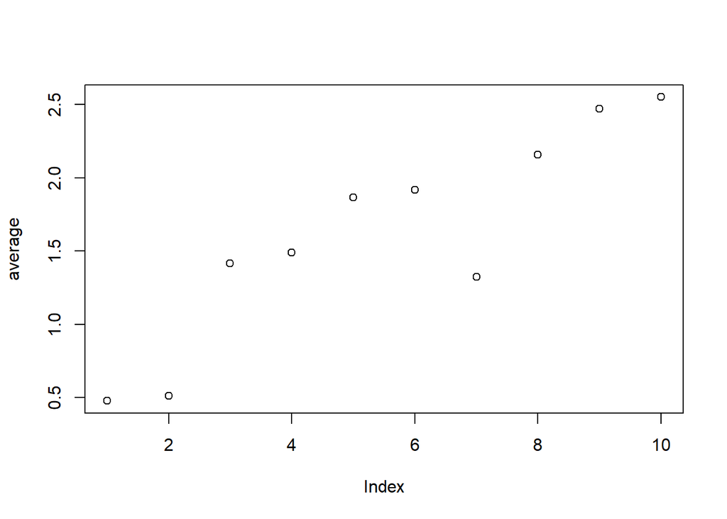

```r
average= c(x1_1,x2_1,x3_1,x4_1,x5_1,x6_1,x7_1,x8_1,x9_1,x10_1)
plot(average)
```

```r
#install.packages("DMwR")
#install.packages("ClassDiscovery")
#install.packages("MASS")
library("MASS")
library("DMwR")
library("data.table")
library("ClassDiscovery")
```

Q2

For the sake of simplicity, we have used Mass library to access Boston data set directly. We started by exploring the data set first.

```r
data=Boston
str(data)
```

```
## 'data.frame':    506 obs. of  14 variables:
##  $ crim   : num  0.00632 0.02731 0.02729 0.03237 0.06905 ...
##  $ zn     : num  18 0 0 0 0 0 12.5 12.5 12.5 12.5 ...
##  $ indus  : num  2.31 7.07 7.07 2.18 2.18 2.18 7.87 7.87 7.87 7.87 ...
##  $ chas   : int  0 0 0 0 0 0 0 0 0 0 ...
##  $ nox    : num  0.538 0.469 0.469 0.458 0.458 0.458 0.524 0.524 0.524 0.524 ...
##  $ rm     : num  6.58 6.42 7.18 7 7.15 ...
##  $ age    : num  65.2 78.9 61.1 45.8 54.2 58.7 66.6 96.1 100 85.9 ...
##  $ dis    : num  4.09 4.97 4.97 6.06 6.06 ...
##  $ rad    : int  1 2 2 3 3 3 5 5 5 5 ...
##  $ tax    : num  296 242 242 222 222 222 311 311 311 311 ...
##  $ ptratio: num  15.3 17.8 17.8 18.7 18.7 18.7 15.2 15.2 15.2 15.2 ...
##  $ black  : num  397 397 393 395 397 ...
##  $ lstat  : num  4.98 9.14 4.03 2.94 5.33 ...
##  $ medv   : num  24 21.6 34.7 33.4 36.2 28.7 22.9 27.1 16.5 18.9 ...
```

```r
summary(data)
```

```
##       crim                zn             indus            chas
##  Min.   : 0.00632   Min.   :  0.00   Min.   : 0.46   Min.   :0.00000
##  1st Qu.: 0.08204   1st Qu.:  0.00   1st Qu.: 5.19   1st Qu.:0.00000
##  Median : 0.25651   Median :  0.00   Median : 9.69   Median :0.00000
##  Mean   : 3.61352   Mean   : 11.36   Mean   :11.14   Mean   :0.06917
##  3rd Qu.: 3.67708   3rd Qu.: 12.50   3rd Qu.:18.10   3rd Qu.:0.00000
##  Max.   :88.97620   Max.   :100.00   Max.   :27.74   Max.   :1.00000
##       nox               rm             age              dis
##  Min.   :0.3850   Min.   :3.561   Min.   :  2.90   Min.   : 1.130
##  1st Qu.:0.4490   1st Qu.:5.886   1st Qu.: 45.02   1st Qu.: 2.100
##  Median :0.5380   Median :6.208   Median : 77.50   Median : 3.207
##  Mean   :0.5547   Mean   :6.285   Mean   : 68.57   Mean   : 3.795
##  3rd Qu.:0.6240   3rd Qu.:6.623   3rd Qu.: 94.08   3rd Qu.: 5.188
##  Max.   :0.8710   Max.   :8.780   Max.   :100.00   Max.   :12.127
##       rad              tax           ptratio          black
##  Min.   : 1.000   Min.   :187.0   Min.   :12.60   Min.   :  0.32
##  1st Qu.: 4.000   1st Qu.:279.0   1st Qu.:17.40   1st Qu.:375.38
##  Median : 5.000   Median :330.0   Median :19.05   Median :391.44
##  Mean   : 9.549   Mean   :408.2   Mean   :18.46   Mean   :356.67
##  3rd Qu.:24.000   3rd Qu.:666.0   3rd Qu.:20.20   3rd Qu.:396.23
##  Max.   :24.000   Max.   :711.0   Max.   :22.00   Max.   :396.90
##      lstat            medv
##  Min.   : 1.73   Min.   : 5.00
##  1st Qu.: 6.95   1st Qu.:17.02
##  Median :11.36   Median :21.20
##  Mean   :12.65   Mean   :22.53
##  3rd Qu.:16.95   3rd Qu.:25.00
##  Max.   :37.97   Max.   :50.00
```

```r
cor(data)
```

```
##                crim          zn       indus         chas         nox
## crim     1.00000000 -0.20046922  0.40658341 -0.055891582  0.42097171
## zn      -0.20046922  1.00000000 -0.53382819 -0.042696719 -0.51660371
## indus    0.40658341 -0.53382819  1.00000000  0.062938027  0.76365145
## chas    -0.05589158 -0.04269672  0.06293803  1.000000000  0.09120281
## nox      0.42097171 -0.51660371  0.76365145  0.091202807  1.00000000
## rm      -0.21924670  0.31199059 -0.39167585  0.091251225 -0.30218819
## age      0.35273425 -0.56953734  0.64477851  0.086517774  0.73147010
## dis     -0.37967009  0.66440822 -0.70802699 -0.099175780 -0.76923011
## rad      0.62550515 -0.31194783  0.59512927 -0.007368241  0.61144056
## tax      0.58276431 -0.31456332  0.72076018 -0.035586518  0.66802320
## ptratio  0.28994558 -0.39167855  0.38324756 -0.121515174  0.18893268
## black   -0.38506394  0.17552032 -0.35697654  0.048788485 -0.38005064
## lstat    0.45562148 -0.41299457  0.60379972 -0.053929298  0.59087892
## medv    -0.38830461  0.36044534 -0.48372516  0.175260177 -0.42732077
##                  rm         age         dis          rad         tax    ptratio
## crim    -0.21924670  0.35273425 -0.37967009  0.625505145  0.58276431  0.2899456
## zn       0.31199059 -0.56953734  0.66440822 -0.311947826 -0.31456332 -0.3916785
## indus   -0.39167585  0.64477851 -0.70802699  0.595129275  0.72076018  0.3832476
## chas     0.09125123  0.08651777 -0.09917578 -0.007368241 -0.03558652 -0.1215152
## nox     -0.30218819  0.73147010 -0.76923011  0.611440563  0.66802320  0.1889327
## rm       1.00000000 -0.24026493  0.20524621 -0.209846668 -0.29204783 -0.3555015
## age     -0.24026493  1.00000000 -0.74788054  0.456022452  0.50645559  0.2615150
## dis      0.20524621 -0.74788054  1.00000000 -0.494587930 -0.53443158 -0.2324705
## rad     -0.20984667  0.45602245 -0.49458793  1.000000000  0.91022819  0.4647412
## tax     -0.29204783  0.50645559 -0.53443158  0.910228189  1.00000000  0.4608530
## ptratio -0.35550149  0.26151501 -0.23247054  0.464741179  0.46085304  1.0000000
## black    0.12806864 -0.27353398  0.29151167 -0.444412816 -0.44180801 -0.1773833
## lstat   -0.61380827  0.60233853 -0.49699583  0.488676335  0.54399341  0.3740443
## medv     0.69535995 -0.37695457  0.24992873 -0.381626231 -0.46853593 -0.5077867
##               black      lstat       medv
## crim    -0.38506394  0.4556215 -0.3883046
## zn       0.17552032 -0.4129946  0.3604453
## indus   -0.35697654  0.6037997 -0.4837252
## chas     0.04878848 -0.0539293  0.1752602
## nox     -0.38005064  0.5908789 -0.4273208
## rm       0.12806864 -0.6138083  0.6953599
## age     -0.27353398  0.6023385 -0.3769546
## dis      0.29151167 -0.4969958  0.2499287
## rad     -0.44441282  0.4886763 -0.3816262
## tax     -0.44180801  0.5439934 -0.4685359
## ptratio -0.17738330  0.3740443 -0.5077867
## black    1.00000000 -0.3660869  0.3334608
## lstat   -0.36608690  1.0000000 -0.7376627
## medv     0.33346082 -0.7376627  1.0000000
```

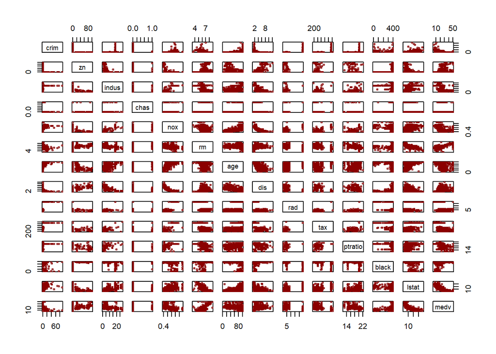

```r
plot(data, col="dark red", cex=.5)
```

We wanted to see interrelations between the features with the naked eye. For this purpose, we ploted the figure above. We obtained interesting insights, what we have seen is that as the value of dis increases nox levels are decreasing, which makes sense. The median value for the house has linear relationship with the room the house has. And finally, we also saw that, this one is not suprisingly though, as the median price increases, % of the lower status of the population decreases exponentially.

```r
#deleting unnecessary factors
x <- Boston[,-7]
y <- x[,-13]

str(y)
```

```
## 'data.frame':    506 obs. of  12 variables:
##  $ crim   : num  0.00632 0.02731 0.02729 0.03237 0.06905 ...
##  $ zn     : num  18 0 0 0 0 0 12.5 12.5 12.5 12.5 ...
##  $ indus  : num  2.31 7.07 7.07 2.18 2.18 2.18 7.87 7.87 7.87 7.87 ...
##  $ chas   : int  0 0 0 0 0 0 0 0 0 0 ...
##  $ nox    : num  0.538 0.469 0.469 0.458 0.458 0.458 0.524 0.524 0.524 0.524 ...
##  $ rm     : num  6.58 6.42 7.18 7 7.15 ...
##  $ dis    : num  4.09 4.97 4.97 6.06 6.06 ...
##  $ rad    : int  1 2 2 3 3 3 5 5 5 5 ...
##  $ tax    : num  296 242 242 222 222 222 311 311 311 311 ...
##  $ ptratio: num  15.3 17.8 17.8 18.7 18.7 18.7 15.2 15.2 15.2 15.2 ...
##  $ black  : num  397 397 393 395 397 ...
##  $ lstat  : num  4.98 9.14 4.03 2.94 5.33 ...
```

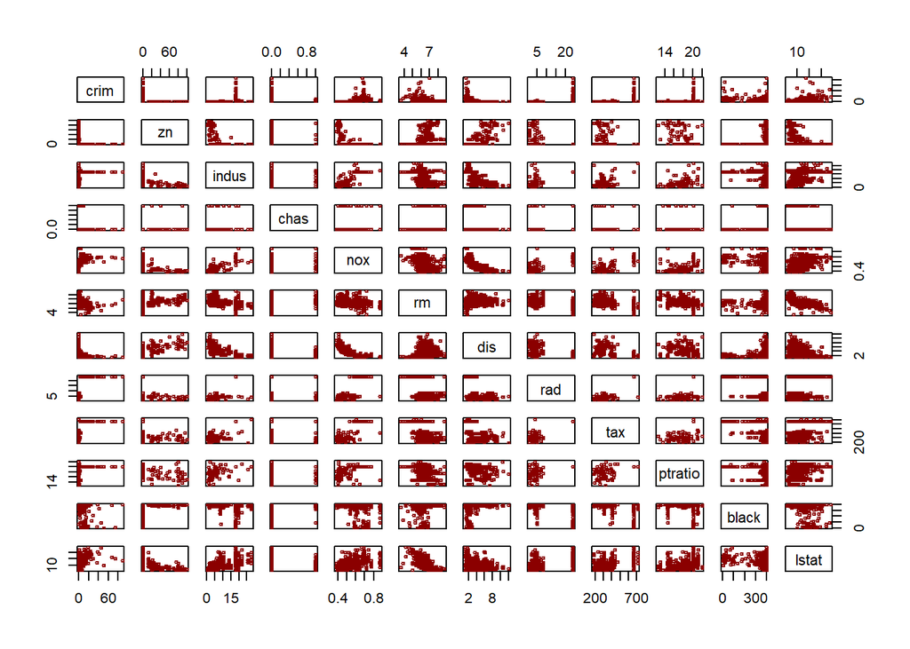

```r
plot(y, col="dark red", cex=.5)
```

However, since the main purpose of the study is to determine main factors that impacts the value of the house, we also wanted to look at what the parameters actually mean one by one. This is where we have seen that there are some parameters that are not necessary linked or very loosely linked with the value of an house. Therefore, we eliminated these parameters to eliminate the noise in the data.

For instance, feature AGE defined as: proportion of owner-occupied units built prior to 1940, whereas, MEDV defined as Median value of owner-occupied homes in $1000’s. We could not see how these features impacts the value of the houses, therefore, decided to not to use them.

```r
#allignment
y$chas=as.numeric(y$chas)
y$rad=as.numeric(y$rad)

str(y)
```

```
## 'data.frame':    506 obs. of  12 variables:
##  $ crim   : num  0.00632 0.02731 0.02729 0.03237 0.06905 ...
##  $ zn     : num  18 0 0 0 0 0 12.5 12.5 12.5 12.5 ...
##  $ indus  : num  2.31 7.07 7.07 2.18 2.18 2.18 7.87 7.87 7.87 7.87 ...
##  $ chas   : num  0 0 0 0 0 0 0 0 0 0 ...
##  $ nox    : num  0.538 0.469 0.469 0.458 0.458 0.458 0.524 0.524 0.524 0.524 ...
##  $ rm     : num  6.58 6.42 7.18 7 7.15 ...
##  $ dis    : num  4.09 4.97 4.97 6.06 6.06 ...
##  $ rad    : num  1 2 2 3 3 3 5 5 5 5 ...
##  $ tax    : num  296 242 242 222 222 222 311 311 311 311 ...
##  $ ptratio: num  15.3 17.8 17.8 18.7 18.7 18.7 15.2 15.2 15.2 15.2 ...
##  $ black  : num  397 397 393 395 397 ...
##  $ lstat  : num  4.98 9.14 4.03 2.94 5.33 ...
```

Ensured the the data is alligned.

```r
pca <- princomp(y, cor=TRUE)
summary(pca, loadings=TRUE)
```

```
## Importance of components:
##                          Comp.1    Comp.2    Comp.3     Comp.4     Comp.5
## Standard deviation     2.360195 1.1466422 1.1143615 0.91472156 0.91238750
## Proportion of Variance 0.464210 0.1095657 0.1034835 0.06972629 0.06937091
## Cumulative Proportion  0.464210 0.5737757 0.6772591 0.74698540 0.81635632
##                            Comp.6     Comp.7     Comp.8    Comp.9    Comp.10
## Standard deviation     0.80927326 0.72910683 0.54835692 0.5241176 0.45421345
## Proportion of Variance 0.05457693 0.04429973 0.02505794 0.0228916 0.01719249
## Cumulative Proportion  0.87093325 0.91523298 0.94029092 0.9631825 0.98037501
##                           Comp.11     Comp.12
## Standard deviation     0.41429719 0.252700806
## Proportion of Variance 0.01430351 0.005321475
## Cumulative Proportion  0.99467853 1.000000000
##
## Loadings:
##         Comp.1 Comp.2 Comp.3 Comp.4 Comp.5 Comp.6 Comp.7 Comp.8 Comp.9 Comp.10
## crim     0.272  0.280  0.270  0.131         0.198  0.788         0.278
## zn      -0.261  0.351  0.329  0.376         0.293 -0.326 -0.328  0.302 -0.377
## indus    0.362 -0.173                       0.105 -0.304         0.623  0.520
## chas           -0.560  0.238  0.600  0.479 -0.188
## nox      0.352 -0.269               -0.229  0.182 -0.166               -0.370
## rm      -0.206 -0.147  0.587 -0.490  0.108               -0.506 -0.118  0.229
## dis     -0.326  0.391         0.267  0.140        -0.145  0.138 -0.105  0.502
## rad      0.345  0.203  0.303         0.248  0.140 -0.134  0.238 -0.421
## tax      0.364  0.174  0.233         0.169  0.197 -0.307  0.184 -0.129  0.130
## ptratio  0.224  0.300 -0.302 -0.198  0.636 -0.305        -0.305  0.189 -0.277
## black   -0.220 -0.199 -0.317 -0.120  0.374  0.797
## lstat    0.323        -0.262  0.338 -0.217               -0.648 -0.427  0.217
##         Comp.11 Comp.12
## crim     0.116
## zn      -0.127
## indus           -0.251
## chas
## nox      0.736
## rm       0.103
## dis      0.587
## rad     -0.114  -0.632
## tax     -0.170   0.724
## ptratio  0.156
## black
## lstat
```

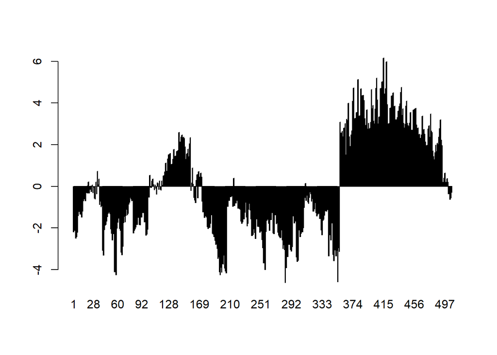

```r
#Examining Col.1
barplot(pca$scores[,1])
```

In the summary, we have seen that comp.1 is explaining the variance the best solely in 1 dimension. Therefore we dived deeper into how the data explained with this comp.

When we look at the summary, we see that Comp.1 takes all features into account except chas feature. On the other hand, when we examined the bor plot, we have seen that there are some clear distinct groups. For instance, while obsveravations between 180-350 (say its Group 1) seems to have an weight on negative coefficients more, whereas houses between 350 to 500 (say its Group 2), have weight on positive coefficients. From here, we can make some infurances such as Group 1 houses are in the residential areas, have high number of rooms, far away from the employement centers, and black population is higher. With the same logic, we can make inferences for the Group 2 as well by focusing on the positive coefficients.

```r
netflixdata=read.csv("C:/Users/ALPER YILMAZ/Desktop/BOUN/2020/Business Analytics/HW1/Netflix_Final.csv")
str(netflixdata)
```

```
## 'data.frame':    10000 obs. of  100 variables:
##  $ ï..Miss_Congeniality                                  : num  4e+07 4e+07 3e+07 3e+07 5e+07 5e+07 3e+07 3e+07 5e+07 4e+07 ...
##  $ Independence_Day                                      : num  4e+07 4e+07 4e+07 4e+07 5e+07 4e+07 4e+07 3e+07 4e+07 4e+07 ...
##  $ The_Patriot                                           : num  5e+07 5e+07 4e+07 4e+07 5e+07 5e+07 5e+07 4e+07 4e+07 5e+07 ...
##  $ The_Day_After_Tomorrow                                : num  4e+07 4e+07 4e+07 3e+07 4e+07 2e+07 3e+07 3e+07 3e+07 3e+07 ...
##  $ Pirates_of_the_Caribbean._The_Curse_of_the_Black_Pearl: num  5e+07 5e+07 5e+07 5e+07 5e+07 4e+07 4e+07 5e+07 5e+07 5e+07 ...
##  $ Pretty_Woman                                          : num  3e+07 4e+07 5e+07 4e+07 4e+07 5e+07 4e+07 5e+07 4e+07 3e+07 ...
##  $ Forrest_Gump                                          : num  5e+07 5e+07 4e+07 4e+07 5e+07 5e+07 5e+07 5e+07 5e+07 4e+07 ...
##  $ The_Green_Mile                                        : num  5e+07 5e+07 4e+07 4e+07 5e+07 4e+07 5e+07 4e+07 5e+07 4e+07 ...
##  $ Con_Air                                               : num  5e+07 2e+07 3e+07 4e+07 4e+07 4e+07 3e+07 4e+07 4e+07 5e+07 ...
##  $ Twister                                               : num  4e+07 5e+07 3e+07 4e+07 5e+07 4e+07 4e+07 3e+07 4e+07 4e+07 ...
##  $ Sweet_Home_Alabama                                    : num  5e+07 5e+07 4e+07 3e+07 4e+07 5e+07 3e+07 4e+07 4e+07 3e+07 ...
##  $ Pearl_Harbor                                          : num  3e+07 5e+07 3e+07 3e+07 4e+07 3e+07 3e+07 4e+07 4e+07 4e+07 ...
##  $ Armageddon                                            : num  5e+07 3e+07 4e+07 4e+07 5e+07 5e+07 4e+07 3e+07 3e+07 5e+07 ...
##  $ The_Rock                                              : num  3e+07 4e+07 3e+07 4e+07 5e+07 5e+07 4e+07 4e+07 4e+07 5e+07 ...
```

[output cut: 86 more lines]

```r
#taking transpose for the sampling purposes
transposed_nd=transpose(netflixdata)

samp_tran_nd=sample(transposed_nd,1000)

#reversing it back
samp_nd=transpose(samp_tran_nd)

#imputating the NA with kNNImputation method
knn.nd=knnImputation(samp_nd,k=10)
```

We have been provided by two data sets, one of which was related to titles of the movies, the other one was respective ratings by the observers. In order to initiate our study, we needed to combine these two. Since it was relatively much easier to do in Excel, we prefered to complete it there. However, since the hardware requirement in the following activities are quite high, we sampled the 1000 observations randomly and for this purpose we first transposed the data and then reversed it back after sampling. From here, we moved on to impute the missing values. For this, we used k nearest neighbour imputation method we found as a quite reasonable method. kNN determines the missing value by looking out the people who have similar ratings in other movies with the people has not given rating and fills the value by making calculation on those peoples ratings for the target missing value.

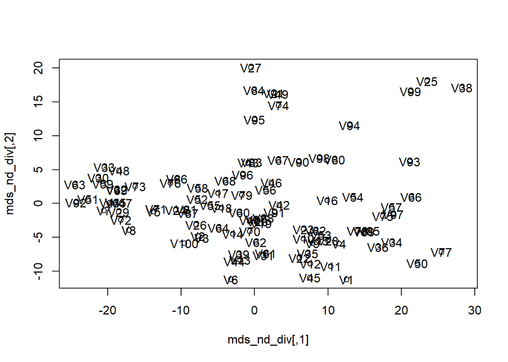

```r
#creating the distance matrix
f = distanceMatrix(knn.nd,'euclid')

#preparing distance function for clasical multidimensional scaling
mat_knn_nd=as.matrix(f)
#executing classical multidimensional scaling
mds_netflix=cmdscale(mat_knn_nd)

#dividing unnecessary numbers
mds_nd_div=mds_netflix/10000000

#ploting the result
plot(mds_nd_div)
text(mds_nd_div, names(knn.nd))
```

In order to perform classical multidimensional scaling, we need to calculate distances between observations first. Then, we should also provide it in matrix format. After we executed the mds, we found out the plot below. We had a really hard time to make inferences about it, and let’s admit it, we could not. In order to create an index in this model, -maybe even with it, the characterization could be quite hard-, one should have great movie culture we believe :) This is where we see that performing rigorous data analysis is one thing but the insight about the analysis topic is quite important to make inferences.